### 2

**Interpretation**: All parts of this question refer to the logistic regression model you just fit.

1. What is the model’s predicted probability for a civil war in India in the period beginning 1975? What probability would it predict for a country just like India in 1975, except that its male secondary school enrollment rate was 30 points higher? What probability would it predict for a country just like India in 1975, except that the ratio of commodity exports to GDP was 0.1 higher?

```r
india.1975 <- war[which(war$country=="India" & war$year==1975),]
plogis(coef(namod)%*%unlist(c(1,india.1975[-c(1:3)],india.1975[4]^2)))
```

```
##           [,1]
## [1,] 0.3504199
```

The model’s predicted probability for a civil war in India in the period beginning 1975 is 35.04%.

```r
plogis(coef(namod)%*%(unlist(c(1,india.1975[-c(1:3)],india.1975[4]^2))+ c(0,0,30,rep(0,7))))
```

```
##         [,1]
## [1,] 0.17309
```

If everything else remains the same for India in the period beginning 1975, but the male secondary school enrollment rate increases by 30 percentage points, then the predicted probability of war decreases by more than half to 17.31%.

```r
tmp <- unlist(c(1,india.1975[-c(1:3)])) + c(0,.1,rep(0,7))
tmp <- c(tmp,tmp[2]^2)
plogis(coef(namod)%*%tmp)
```

```
##           [,1]
## [1,] 0.6961378
```

If everything else remains the same for India in the period beginning 1975, except the ratio of commodity exports to GDP was 0.1 higher, then the predicted probability of war almost doubles to 69.61%.

2. What is the model’s predicted probability for a civil war in Nigeria in the period beginning 1965? What probability would it predict for a country just like Nigeria in 1965, except that its male secondary school enrollment rate was 30 points higher? What probability would it predict for a country just like Nigeria in 1965, except that the ratio of commodity exports to GDP was 0.1 higher?

```r
nigeria.1965 <-  war[which(war$country=="Nigeria" & war$year==1965),]
plogis(coef(namod)%*%unlist(c(1,nigeria.1965[-c(1:3)],nigeria.1965[4]^2)))
```

```
##           [,1]
## [1,] 0.1709917
```

The model’s predicted probability for a civil war in Nigeria in the period beginning 1965 is 17.10%.

```r
plogis(coef(namod)%*%(unlist(c(1,nigeria.1965[-c(1:3)],nigeria.1965[4]^2))+ c(0,0,30,rep(0,7))))
```

```
##            [,1]
## [1,] 0.07410315
```

If everything else remains the same for Nigeria in the period beginning 1965, but the male secondary school enrollment rate increases by 30 percentage points, then the predicted probability of war decreases by more than half to 7.41%.

```r
tmp <- unlist(c(1,nigeria.1965[-c(1:3)])) + c(0,.1,rep(0,7))
tmp <- c(tmp,tmp[2]^2)
plogis(coef(namod)%*%tmp)
```

```
##           [,1]
## [1,] 0.3310044
```

If everything else remains the same for Nigeria in the period beginning 1965, except the ratio of commodity exports to GDP was 0.1 higher, then the predicted probability of war almost doubles to 33.10%.

3. In the parts above, you changed the same predictor variables by the same amounts. If you did your calculations properly, the changes in predicted probabilities are not equal. Explain why not. (The reasons may or may not be the same for the two variables.)

**Solution (by James Lepore)** he primary reason that the changes in predicted probabilities are not equal in magnitude is that the coefficients of a logistic regression model with a logit link measure changes in log odds. To put it in perhaps a simpler light, when the coefficient of a logit is small in magnitude (i.e. less < .1), the coefficient can actually be thought of as an approximation of the percent change for every one unit increase. The percent change in predicted probability is obviously dependent on the baseline and starting input values. India in 1975 (35.04%) and Nigeria in 1965 (17.09%) are starting from two very different places, and the male secondary school enrollment rates are also quite different (36% for India versus 7% for Nigeria). This is in contrast to a linear regression where the coefficients measure the linear effect of a one unit increase in the input (meaning the base and starting value are irrelevant). That being said, even in a regular regression model we would still observe a different magnitude change in predicted probabilites for equivalent increases in the ratio of commodity exports to GDP. The reasoning why is quite similar. If you recall, we modeled the exports variable with an additional quadratic term, meaning the linear interpretation of the coefficients continues to no longer be applicable because once again the starting input values will matter. For example, a .1 increase from .026 (India 1975) will result in a .0152 increase in the quadratic input. Whereas a .1 increase from .123 (Nigeria 1965) will result in a .0346 quadratic input (more than double the magnitude).

### 3

**Confusion**: Logistic regression predicts a probability of civil war for each country and period. Suppose we want to make a definite prediction of civil war or not, that is, to classify each data point. The probability of misclassification is minimized by predicting war if the probability is ≥ 0.5, and peace otherwise.

1. Build a 2 × 2 *confusion matrix* (a.k.a. “classification table” or “contigency table”) which counts: the number of outbreaks of civil war correctly predicted by the logistic regression; the number of civil wars not predicted by the model; the number of false predictions of civil wars; and the number of correctly predicted absences of civil wars. (Note that some entries in the table may be zero.)
2. What fraction of the logistic regression’s predictions are incorrect, i.e. what is the misclassification rate? (Note that this is if anything too kind to the model, since it’s looking at predictions to the same training data set).
3. Consider a foolish (?) pundit who always predicts “no war”. What fraction of the pundit’s predictions are correct on the whole data set? What fraction are correct on data points where the logistic regression model also makes a prediction?

**Solution**

```r
confuse <- function(x,xhat){
  cm <- matrix(c(sum(x==1&xhat==1),
           sum(x==0&xhat==1),
           sum(x==1&xhat==0),
           sum(x==0&xhat==0)),2,2,byrow=T)
  ac <- (sum(x==1&xhat==1)+sum(x==0&xhat==0))/length(x)
  list(cm=cm,ac=ac)
}
### test our dataset with all missing values removed
print(confuse(namod$model[,1],as.numeric(fitted.values(namod)>.5)))
```

```
## $cm
##      [,1] [,2]
## [1,]    3    5
## [2,]   43  637
##
## $ac
## [1] 0.9302326
```

```r
print(confuse(namod$model[,1],rep(0,nrow(namod$model))))
```

```
## $cm
##      [,1] [,2]
## [1,]    0    0
## [2,]   46  642
##
## $ac
## [1] 0.9331395
```

```r
print(confuse(war[inds,"start"],rep(0,length(inds))))
```

```
## $cm
##      [,1] [,2]
## [1,]    0    0
## [2,]   78 1089
##
## $ac
## [1] 0.933162
```

The pundit achieves 93% accuracy on both datasets. Because war is rare, the pundit outperforms the logistic regression in terms of predictive accuracy.

### 4

**Comparison**: Since this is a classification problem with only two classes, we can compare Logistic Regression right along side Discriminant Analysis.

1. Fit an LDA model using the same predictors that you used for your logistic regression model. What is the training misclassification rate?
2. Fit a QDA model using the very same predictors. What is the training misclassification rate?
3. How does the prediction accuracy of the three models compare? Why do you think this is?

**Solution**

```r
library(MASS)
library(e1071)
library(nnet)

trset <- sample(c(1:1167),750,replace=F)
ttset <- setdiff(c(1:1167),trset)
lda_mod <- qda_mod <- svm_mod <- nnet_mod <- knn_mod <- rf_mod <- list()
for (m in c(1:M)){
  mydat <- cbind(mdat[,"start"],imputed_war$imputations[[m]][,-c(1:2)],imputed_war$imputation[[m]][,"exports"]^2)
  colnames(mydat)[c(1,10)] <- c("start","exports2")
  mydat <- na.omit(mydat)
  lda_mod[[m]] <- lda(start~.,data=mydat)
  qda_mod[[m]] <- qda(start~.,data=mydat)
  svm_mod[[m]] <- svm(as.factor(start)~.,data=mydat,probability=T)
  nnet_mod[[m]] <- nnet(as.factor(start)~.,data=mydat,size=10,skip=F)
}
```

Let’s generate predictions for the models.

```r
confuse <- function(x,xhat){
  cm <- matrix(c(sum(x==1&xhat==1),
           sum(x==0&xhat==1),
           sum(x==1&xhat==0),
           sum(x==0&xhat==0)),2,2,byrow=T)
  ac <- (sum(x==1&xhat==1)+sum(x==0&xhat==0))/length(x)
  list(cm=cm,ac=ac)
}
### test our dataset with all missing values removed
print(confuse(tdat[,"start"],as.numeric(fitted.values(namod)>.5)))
```

```
## $cm
##      [,1] [,2]
## [1,]    3    5
## [2,]   43  637
##
## $ac
## [1] 0.9302326
```

```r
for (m in c(1:M)){
  mydat <- cbind(mdat[,"start"],imputed_war$imputations[[m]][,-c(1:2)],imputed_war$imputation[[m]][,"exports"]^2)
  colnames(mydat)[c(1,10)] <- c("start","exports2")
  #mydat <- na.omit(mydat)
  ## try each of the imputed models on the original data
  print(confuse(namod$model[,1],as.numeric(predict(mod[[m]],namod$model[,-1],type="response")>.5)))
  print(confuse(namod$model[,1],as.numeric(predict(lda_mod[[m]],namod$model[,-1])$class)-1))
  print(confuse(namod$model[,1],as.numeric(predict(qda_mod[[m]],namod$model[,-1])$class)-1))

  #print(confuse(mydat[,"start"],as.numeric(as.character(predict(svm_mod[[m]],mydat)))))
  #print(confuse(mydat[,"start"],as.numeric(as.character(predict(nnet_mod[[m]],mydat,type="class")))))
}
```

```
## $cm
##      [,1] [,2]
## [1,]    4    4
## [2,]   42  638
##
## $ac
## [1] 0.9331395
##
## $cm
##      [,1] [,2]
## [1,]    4    3
## [2,]   42  639
##
## $ac
## [1] 0.934593
##
## $cm
##      [,1] [,2]
## [1,]   17   26
## [2,]   29  616
##
## $ac
## [1] 0.9200581
##
## $cm
##      [,1] [,2]
## [1,]    1    1
## [2,]   45  641
##
## $ac
## [1] 0.9331395
##
## $cm
##      [,1] [,2]
## [1,]    4    2
## [2,]   42  640
##
## $ac
## [1] 0.9360465
##
```

[output cut: 64 more lines]

```
## $cm
##      [,1] [,2]
## [1,]    4    3
## [2,]   42  639
##
## $ac
## [1] 0.934593
##
## $cm
##      [,1] [,2]
## [1,]   14   26
## [2,]   32  616
##
## $ac
## [1] 0.9156977
```

```r
## Now try using the averaged coefficients on the orginial data

p2 <- avgcoefs %*% t(cbind(rep(1,nrow(tdat)),namod$model[,-1]))
p2 <- plogis(p2)
print(confuse(namod$model[,1],as.numeric(p2)>.5))
```

```
## $cm
##      [,1] [,2]
## [1,]    4    2
## [2,]   42  640
##
## $ac
## [1] 0.9360465
```

We see that imputation improved predictive accuracy by a modest amount (93% to 93.6%). Quadratic Discriminant Analysis does the worst - it overpredicts conflict. This suggests the assumptions for QDA; the covariance matrices of data from the two populations may not be different.

```r
cov(namod$model[namod$model[,1]==1,-1]);cov(namod$model[namod$model[,1]==0,-1])
```

```
##                        exports     schooling        growth         peace
## exports            0.013734932  3.347430e-01 -5.201740e-02    -0.7146895
## schooling          0.334742981  4.541430e+02 -7.050352e-01   963.2772947
## growth            -0.052017403 -7.050352e-01  1.883964e+01   200.3635972
## peace             -0.714689470  9.632773e+02  2.003636e+02 25261.4516908
## concentration      0.003573549  3.860261e-01 -1.029378e-01     0.3046644
## lnpop             -0.035639042  8.305714e+00  1.034554e+00   -18.7643382
## fractionalization 39.748800064 -1.050220e+04 -1.392819e+03 -8483.7787440
## dominance         -0.007840097  3.282126e+00  2.696488e-01    11.6458937
## exports2           0.006844053  1.948348e-01 -1.394775e-02     0.1993663
##                   concentration        lnpop fractionalization
## exports             0.003573549  -0.03563904          39.74880
## schooling           0.386026142   8.30571384      -10502.20290
## growth             -0.102937778   1.03455429       -1392.81911
## peace               0.304664361 -18.76433818       -8483.77874
## concentration       0.021648497   0.01202354          32.86380
## lnpop               0.012023542   1.58840748         668.08290
## fractionalization  32.863803113 668.08290332     4658309.19420
## dominance           0.021932850  -0.10191086        -268.43575
## exports2            0.001436687  -0.01208167          17.56231
##                       dominance     exports2
## exports           -7.840097e-03  0.006844053
## schooling          3.282126e+00  0.194834793
## growth             2.696488e-01 -0.013947746
## peace              1.164589e+01  0.199366251
## concentration      2.193285e-02  0.001436687
## lnpop             -1.019109e-01 -0.012081674
## fractionalization -2.684357e+02 17.562306365
## dominance          2.536232e-01 -0.004318499
## exports2          -4.318499e-03  0.003708247
```

```
##                         exports     schooling        growth         peace
## exports            0.0203024082 -6.301679e-01 -1.575944e-02  1.318653e+00
## schooling         -0.6301679332  9.758338e+02  1.397652e+01  1.893692e+03
## growth            -0.0157594390  1.397652e+01  1.174926e+01 -9.467543e+01
## peace              1.3186532783  1.893692e+03 -9.467543e+01  2.475513e+04
## concentration     -0.0006355493  4.281545e-01  1.529748e-02 -1.777519e+00
## lnpop             -0.0944846982  7.296468e+00  3.312554e-01 -4.177952e+01
## fractionalization 74.0309327594 -2.300489e+04 -1.223807e+03 -4.565008e+04
## dominance          0.0056713273  5.407478e-01 -1.851822e-02  7.328240e+00
## exports2           0.0113783139 -2.665183e-01  5.679912e-03  8.645088e-01
##                   concentration         lnpop fractionalization
## exports           -6.355493e-04   -0.09448470          74.03093
## schooling          4.281545e-01    7.29646773      -23004.89258
## growth             1.529748e-02    0.33125538       -1223.80663
## peace             -1.777519e+00  -41.77952034      -45650.08321
## concentration      4.486306e-02    0.07036531         -62.17913
## lnpop              7.036531e-02    2.58802961        -333.96311
## fractionalization -6.217913e+01 -333.96310946     3919227.97660
## dominance         -4.487683e-03   -0.11420731          18.26250
## exports2          -7.903819e-05   -0.04272432          31.45430
##                      dominance      exports2
## exports            0.005671327  1.137831e-02
## schooling          0.540747761 -2.665183e-01
## growth            -0.018518223  5.679912e-03
## peace              7.328240045  8.645088e-01
## concentration     -0.004487683 -7.903819e-05
## lnpop             -0.114207314 -4.272432e-02
## fractionalization 18.262503584  3.145430e+01
## dominance          0.246502010  4.475761e-03
## exports2           0.004475761  7.311408e-03
```

**Challenge problem**: Using the code available on the week 6 page, construct an ROC curve for your logistic regression model. For an extra challenge, plot the ROC curves of all three models on the same plot.

**Solution**: The ROC curve is created by plotting the true positive rate (TPR) against the false positive rate (FPR) at various threshold settings. That is, compute
$${\mathit {TPR}(t)}={\mathit {TP}(t)}/P$$
and
$${\mathit {FPR}(t)}={\mathit {FP}(t)}/N$$
for all $t$ in a sequence of threshold values from zero to one.

```r
myroc <- function(x,xhat,myt){
  tmp <- NULL
  for (j in c(1:length(myt))){
    fpr <- sum(x==0&xhat>myt[j])/sum(x==0)
    tpr <- sum(x==1&xhat>myt[j])/sum(x==1)
    tmp <- rbind(tmp,c(fpr,tpr))
  }
  return(tmp)
}
#plot(myroc(mydat[,"start"],as.numeric(fitted.values(mod[[m]])),seq(from=0,to=1,by=.01)),
#     xlab="FPR",ylab="TPR",pch=20)
library(ROCR)
pred0 <- prediction( namod$fitted.values, namod$model[,1])
pred <- prediction( as.numeric(predict(mod[[1]],namod$model[,-1])), namod$model[,1])
pred2 <- prediction( as.numeric(predict(lda_mod[[1]],namod$model[,-1])$posterior[,2]), namod$model[,1])
pred3 <- prediction( as.numeric(predict(qda_mod[[1]],namod$model[,-1])$posterior[,2]), namod$model[,1])

pred4 <-  prediction(t(p2),namod$model[,1])
#pred4 <- prediction( as.numeric(as.character(attr(predict(svm_mod[[m]],namod$model[,-1],probability = T),"probabilities")[,2])), namod$model[,1])
#pred5 <- prediction( predict(nnet_mod[[m]],namod$model[,-1],type = "raw"), namod$model[,1])
perf0 <- performance(pred0,"tpr","fpr")
performance(pred0,"auc")
```

```
## An object of class "performance"
## Slot "x.name":
## [1] "None"
##
## Slot "y.name":
## [1] "Area under the ROC curve"
##
## Slot "alpha.name":
## [1] "none"
##
## Slot "x.values":
## list()
##
## Slot "y.values":
## [[1]]
## [1] 0.8597792
##
##
## Slot "alpha.values":
## list()
```

```r
perf <- performance(pred,"tpr","fpr")
performance(pred,"auc")
```

```
## An object of class "performance"
## Slot "x.name":
## [1] "None"
##
## Slot "y.name":
## [1] "Area under the ROC curve"
##
## Slot "alpha.name":
## [1] "none"
##
## Slot "x.values":
## list()
##
## Slot "y.values":
## [[1]]
## [1] 0.8573412
##
##
## Slot "alpha.values":
## list()
```

```r
perf2 <- performance(pred2,"tpr","fpr")
performance(pred2,"auc")
```

```
## An object of class "performance"
## Slot "x.name":
## [1] "None"
##
## Slot "y.name":
## [1] "Area under the ROC curve"
##
## Slot "alpha.name":
## [1] "none"
##
## Slot "x.values":
## list()
##
## Slot "y.values":
## [[1]]
## [1] 0.8437966
##
##
## Slot "alpha.values":
## list()
```

```r
perf3 <- performance(pred3,"tpr","fpr")
performance(pred3,"auc")
```

```
## An object of class "performance"
## Slot "x.name":
## [1] "None"
##
## Slot "y.name":
## [1] "Area under the ROC curve"
##
## Slot "alpha.name":
## [1] "none"
##
## Slot "x.values":
## list()
##
## Slot "y.values":
## [[1]]
## [1] 0.8706488
##
##
## Slot "alpha.values":
## list()
```

```r
perf4 <- performance(pred4,"tpr","fpr")
performance(pred4,"auc")
```

```
## An object of class "performance"
## Slot "x.name":
## [1] "None"
##
## Slot "y.name":
## [1] "Area under the ROC curve"
##
## Slot "alpha.name":
## [1] "none"
##
## Slot "x.values":
## list()
##
## Slot "y.values":
## [[1]]
## [1] 0.8567317
##
##
## Slot "alpha.values":
## list()
```

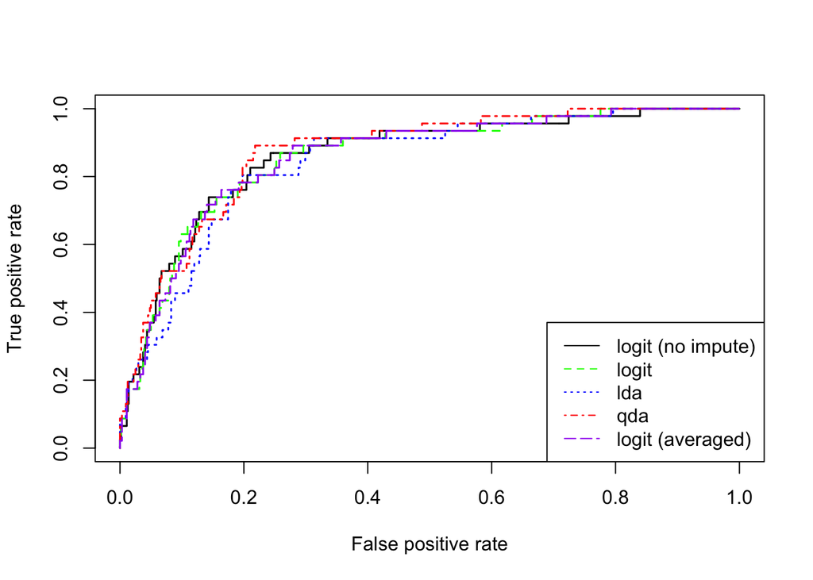

```r
#perf5 <- performance(pred5,"tpr","fpr")

plot(perf0,col="black",lty=1,lwd=1.5)
plot(perf,add=T,col="green",lty=2,lwd=1.5)
plot(perf2,add=T,col="blue",lty=3,lwd=1.5)
plot(perf3,add=T,col="red",lty=4,lwd=1.5)
plot(perf4,add=T,col="purple",lty=5,lwd=1.5)


legend("bottomright",c("logit (no impute)","logit","lda","qda","logit (averaged)"),lty=c(1,2,3,4,5),col=c("black","green","blue","red","purple"))
```

We see that QDA actually has the most area under the curve.

### 6

**Confusion**:

Fit a logistic regression using y as the response with x1 and x2 as indepedent variables. Does anything strange happen? Explain.

```r
y<- c(0,0,0,0,1,1,1,1)
x1<-c(1,2,3,3,5,6,10,11)
x2<-c(3,2,-1,-1,2,4,1,0)
res <- glm(y~x1+x2,family="binomial")
summary(res)
```

```
##
## Call:
## glm(formula = y ~ x1 + x2, family = "binomial")
##
## Deviance Residuals:
##          1           2           3           4           5           6
## -2.110e-08  -1.404e-05  -2.522e-06  -2.522e-06   1.564e-05   2.110e-08
##          7           8
##  2.110e-08   2.110e-08
##
## Coefficients:
##               Estimate Std. Error z value Pr(>|z|)
## (Intercept)    -66.098 183471.722   0.000        1
## x1              15.288  27362.843   0.001        1
## x2               6.241  81543.720   0.000        1
##
## (Dispersion parameter for binomial family taken to be 1)
##
##     Null deviance: 1.1090e+01  on 7  degrees of freedom
## Residual deviance: 4.5454e-10  on 5  degrees of freedom
## AIC: 6
##
## Number of Fisher Scoring iterations: 24
```

The cases have been divided perfectly; there is no uncertainty to quantify. That is,
$$x_1>3\implies y=1.$$
We cannot find the MLE because the parameter associated with $x_1$ will be infinite. Hence inference from the model cannot be used. In fact, there is no need to fit a model.

[^1]: Based on an exercise of Cosmo Shalizi’s that uses data from Collier, Paul and Anke Hoeffler (2004). *Greed and Grievance in Civil War.* Oxford Economic Papers, 56: 563–595. URL: http://economics.ouls.ox.ac.uk/12055/1/2002-01text.pdf.